# Demand for paper and paperboard products in the European Union

- Consumption, Production and Trade
- Consumption
  - Total consumption by Country
  - Consumption of Graphics paper and other paper by Country
  - Consumption and net trade by Country
- GDP by Country
- Prices
- Distributions
- Plot log of the estimation data

### Load data

FAOSTAT is the source of forest products data and World Bank is the source of GDP, deflator and exchange rate data.

```r
print(load("Y:/Macro/forestproductsdemand/enddata/EU27 paper products demand.rdata"))
```

```
## [1] "paperProducts" "ppagg"         "pptrade"       "wb"
```

```r
pp = paperProducts  # Give a shorter name to the data frame
```

## Consumption, Production and Trade Volumes

In the following file, we explore a data table containing paper and paperboard consumption data for **27** countries from 1961 to 2012.  
**In 2012, the overall EU consumption, production and trade in million Tons per item was:**

```
##                           Item Consumption Production Net_Trade Import Export
## 205 Total Paper and Paperboard          80         92        12     49     61
## 206                  Newsprint           7          8         0      5      5
## 207 Printing and Writing Paper          24         32         8     20     27
## 208 Other Paper and Paperboard          49         53         4     24     28
```

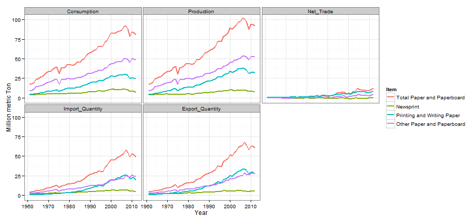

```r
# Consumption, production, trade and net trade at the European Level
ggplot(data = subset(ppagg, !Element %in% c("Import_Value", "Export_Value", "Price"))) +
    geom_line(aes(x = Year, y = Value/1e+06, colour = Item), size = 1) + facet_wrap(~Element) +
    ylab("Million metric Ton") + theme_bw()
```

Net trade is slightly in favor of exports for most products except for newsprint. From bilateral trade statistics (not shown here), we know that most of the trade is happening inside the European Union.

## Consumption

### Consumption by country

Apparent consumption of Total paper and paperboard by country

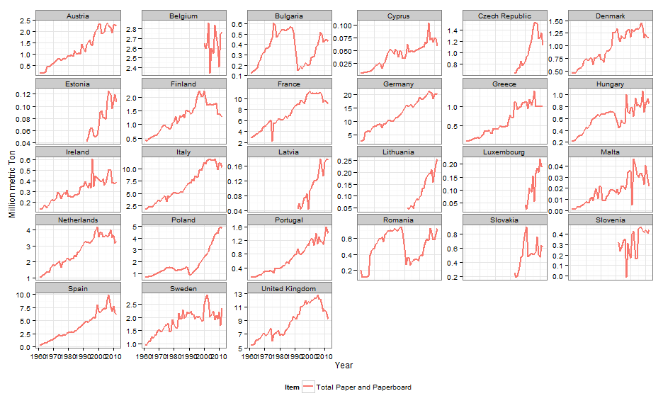

```r
ggplot(data = subset(pp, Item == "Total Paper and Paperboard")) + geom_line(aes(x = Year,
    y = Consumption/1e+06, colour = Item), size = 1) + facet_wrap(~Country, scales = "free_y") +
    xlab("Year") + ylab("Million metric Ton") + theme_bw() + theme(legend.position = "bottom")
```

The largest consumers of paper and paperboard products are France, Germany, Italy, Spain, United Kingdom.

### Apparent consumption of graphics paper and other paper and paperboard by country

```r
# Create a new table with graphics papers following Lauri's comments
ppgraph = subset(pp, Item %in% c("Newsprint", "Printing and Writing Paper"))
nrow(ppgraph)
```

```
## [1] 2275
```

```r
ppgraph = aggregate(ppgraph[c("Consumption", "Net_Trade")], ppgraph[c("Year", "Country")],
    sum)
nrow(ppgraph)
```

```
## [1] 1138
```

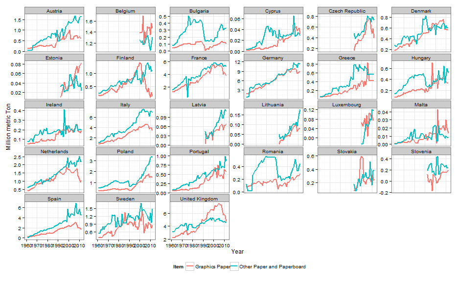

```r
ppgraph$Item = "Graphics Paper"
ppgraph = rbind(ppgraph, subset(pp, Item == "Other Paper and Paperboard", c(Year,
    Country, Item, Consumption, Net_Trade)))

ggplot(data = ppgraph) + geom_line(aes(x = Year, y = Consumption/1e+06, colour = Item),
    size = 1) + facet_wrap(~Country, scales = "free_y") + xlab("Year") + ylab("Million metric Ton") +
    theme_bw() + theme(legend.position = "bottom")
```

```r
scale_colour_manual(values = c("Blue", "Green"))
```

```
## discrete_scale(aesthetics = aesthetic, scale_name = "manual",
##     palette = pal)
```

### Consumption and Net Trade by Country

Apparent consumption and Net Trade of Total paper and paperboard by country

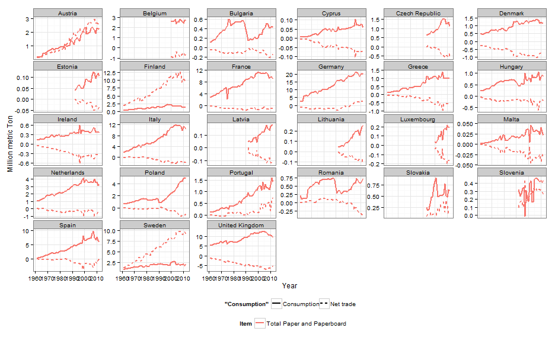

```r
ggplot(data = subset(pp, Item == "Total Paper and Paperboard")) + geom_line(aes(x = Year,
    y = Consumption/1e+06, colour = Item, linetype = "Consumption"), size = 1) +
    geom_line(aes(x = Year, y = Net_Trade/1e+06, colour = Item, linetype = "Net trade"),
        size = 1) + facet_wrap(~Country, scales = "free_y") + xlab("Year") + ylab("Million metric Ton") +
    theme_bw() + theme(legend.position = "bottom")
```

### GDP by country

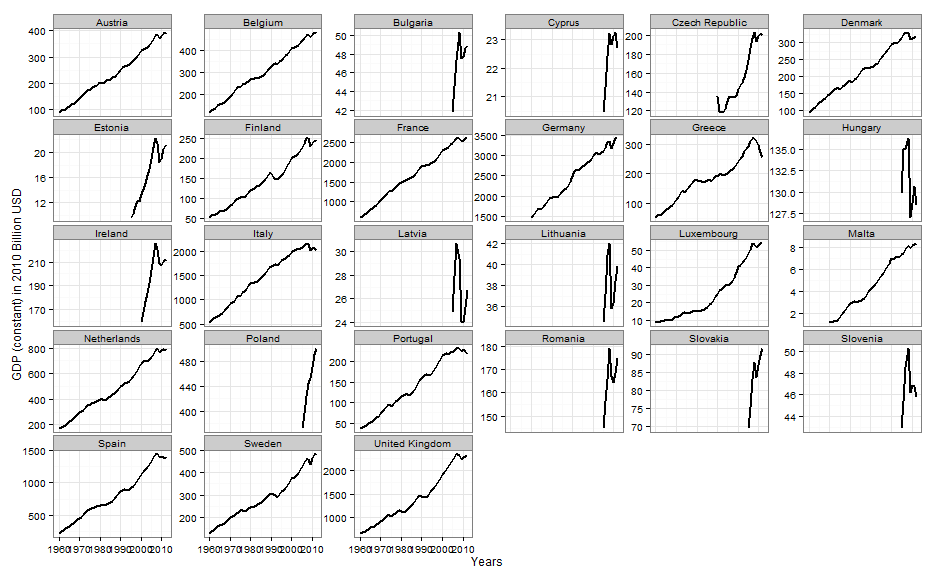

```r
# 1 plot per country
ggplot(data = wb, aes(x = Year, y = GDPconstantUSD/1e+09)) + geom_line(size = 1) +
    xlab("Years") + ylab("GDP (constant) in 2010 Billion USD ") + theme_bw() + theme(legend.position = "none") +
    facet_wrap(~Country, scales = "free_y")
```

## Prices of paper and paperboard

### EU prices

Average trade price of paper products in the European Union

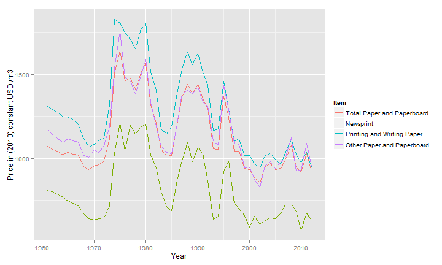

```r
ggplot(data = subset(ppagg, Element == "Price")) + geom_line(aes(x = Year, y = Value,
    color = Item)) + ylab("Price in (2010) constant USD /m3")
```

### Prices per country

Prices are a ponderation of import and export prices as used in Chas-Amil and Buongiorno 2000. Prices are expressed in constant US dollars of 2010.

```
Price = (Import_Value + Export_Value)/
            (Import_Quantity + Export_Quantity) / DeflUS *1000)
```

Countries with a particularly high price were removed from the set.

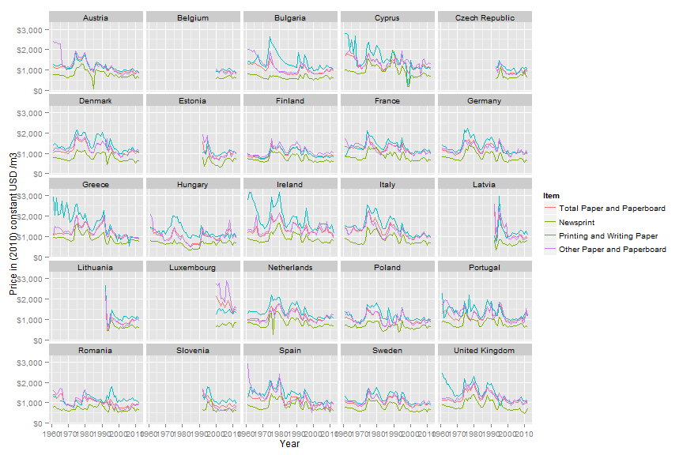

```r
library(scales)
ggplot(data = subset(pp, !Country %in% c("Slovakia", "Malta"))) + geom_line(aes(x = Year,
    y = Price, color = Item)) + facet_wrap(~Country) + ylab("Price in (2010) constant USD /m3") +
    scale_y_continuous(labels = dollar)
```

### Trade prices by Country

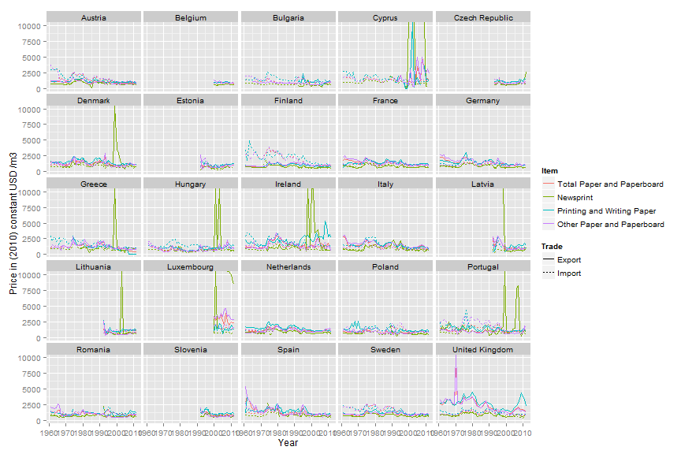

```r
ggplot(data = subset(pptrade, !Country %in% c("Slovakia", "Malta"))) + geom_line(aes(x = Year,
    y = Price_Trade, color = Item, linetype = Trade)) + facet_wrap(~Country) + ylab("Price in (2010) constant USD /m3")
```

### Trade prices for Sweden, Germany, France and Finland

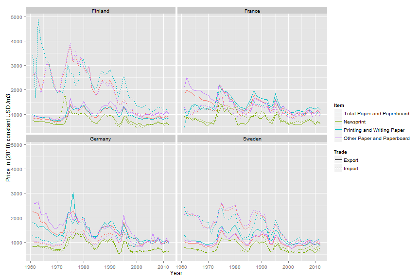

```r
# Sweden Germany France Finland
ggplot(data = subset(pptrade, Country %in% c("Sweden", "Germany", "France", "Finland"))) +
    geom_line(aes(x = Year, y = Price_Trade, color = Item, linetype = Trade)) + facet_wrap(~Country) +
    ylab("Price in (2010) constant USD /m3")
```

## Distribution of the estimation data for 4 important years

## Cross sectional distribution of demand

Number of countries for a given demand volume in million m3

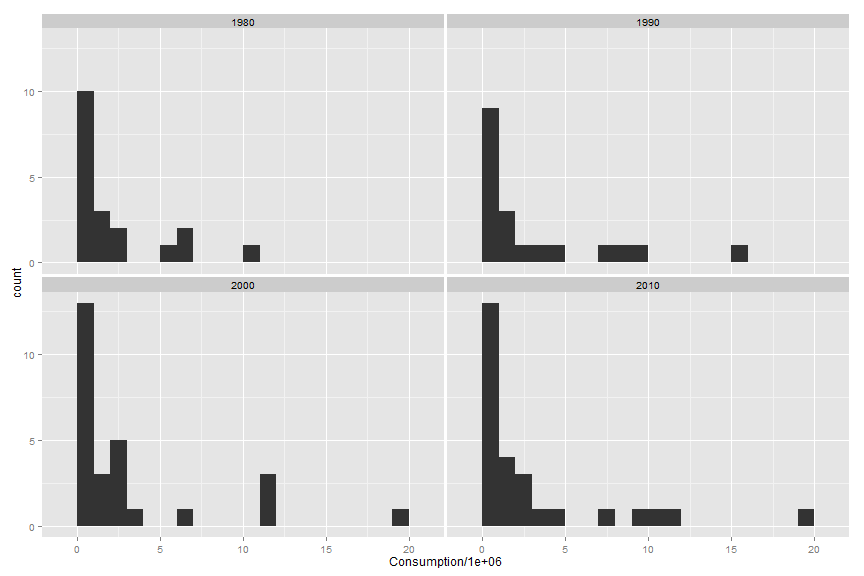

```r
# 1980, 1990, 2000, 2010
pp4hist = subset(pp, Year %in% c(1980, 1990, 2000, 2010) & Item == "Total Paper and Paperboard")
ggplot(data = pp4hist) + geom_histogram(aes(x = Consumption/1e+06), binwidth = 1) +
    facet_wrap(~Year)
```

Number of countries for a given demand volume in log of the volume in m3

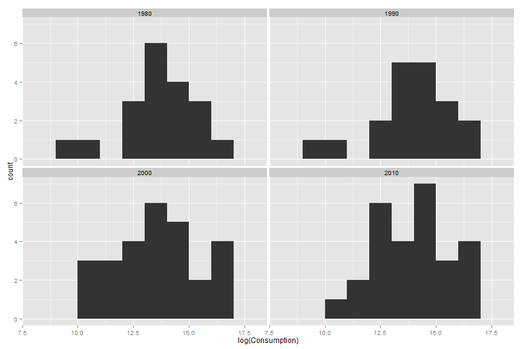

```r
# Consumption in log
ggplot(data = pp4hist) + geom_histogram(aes(x = log(Consumption)), binwidth = 1) +
    facet_wrap(~Year)
```

## Distribution of prices

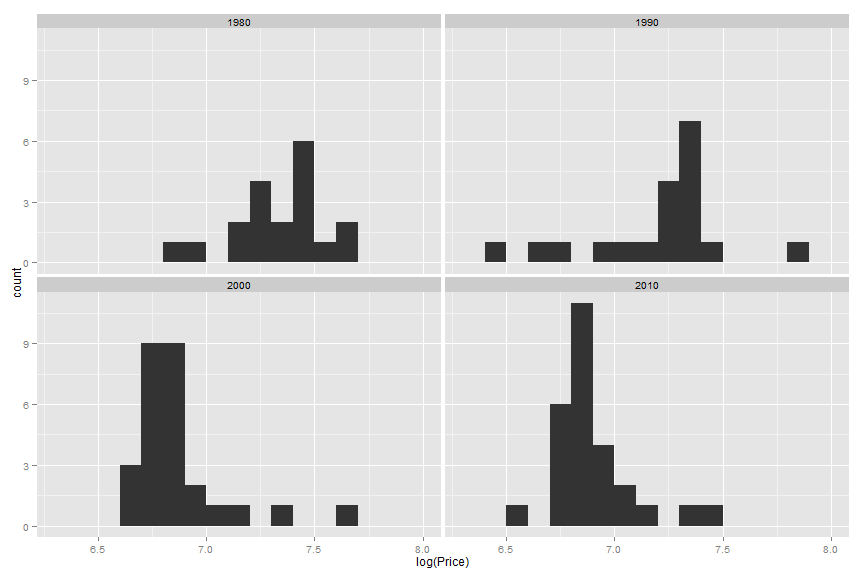

```r
ggplot(data = pp4hist) + geom_histogram(aes(x = log(Price)), binwidth = 0.1) + facet_wrap(~Year)
```

## Distribution of GDP

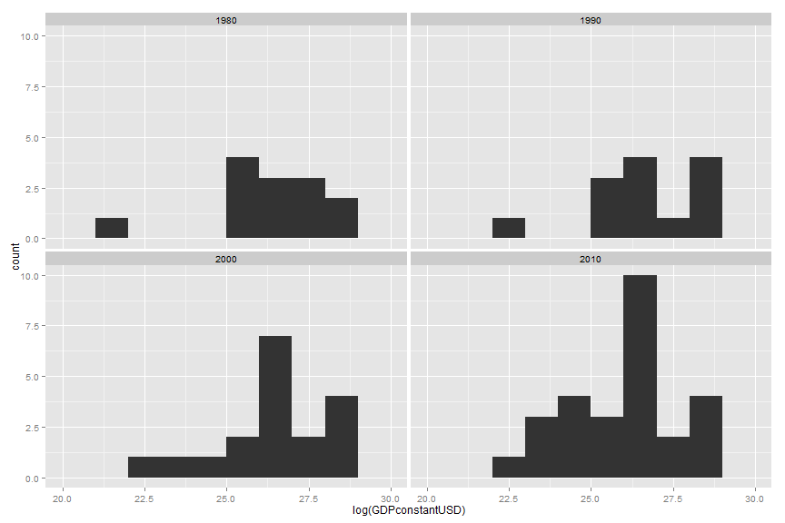

```r
ggplot(data = pp4hist) + geom_histogram(aes(x = log(GDPconstantUSD)), binwidth = 1) +
    facet_wrap(~Year)
```

## Plot log of the estimation data

Lets look at the relationship between log(Consumption) and log(GDP) first.

### Total Paper and Paperboard

2012 data in red

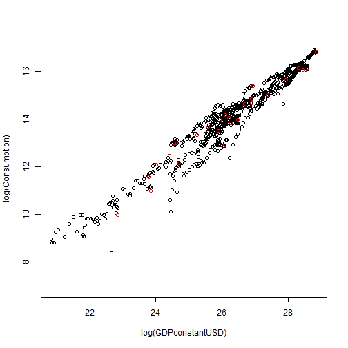

```r
plot(log(Consumption) ~ log(GDPconstantUSD), data = subset(pp, Item == "Total Paper and Paperboard"))
points(log(Consumption) ~ log(GDPconstantUSD), data = subset(pp, Item == "Total Paper and Paperboard" &
    Year == 2012), col = "red")
```

### Explore the influence of Year and Net_Trade by country

Sort countries by Net_Trade, then display a color for each country

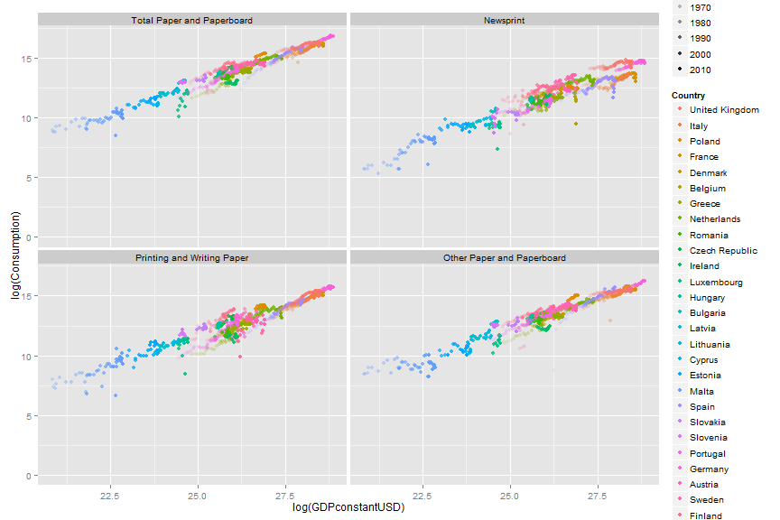

```r
d = data.frame(s = c(45, 43))
ppc = subset(pp, Item == "Total Paper and Paperboard" & Year == 2012)
ppc = ppc[order(ppc$Net_Trade), ]
pp$Country = factor(pp$Country, levels = ppc$Country, ordered = TRUE)
p = ggplot(pp, aes(x = log(GDPconstantUSD), y = log(Consumption))) + facet_wrap(~Item)
p + geom_point(aes(alpha = Year, color = Country))
```

Check the [ggplot shape parameter](http://sape.inf.usi.ch/quick-reference/ggplot2/shape) and the `scale_shape_identity` to improve this graph with a “+” sign for positive net trade and a “o” sign for negative net trade. Plot only Printing and Writing Paper for this graph.

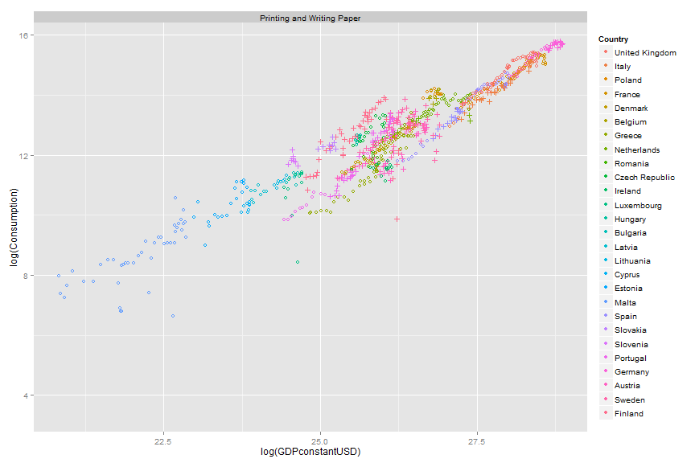

```r
p = ggplot(data = subset(pp, Item == "Printing and Writing Paper"), aes(x = log(GDPconstantUSD),
    y = log(Consumption))) + facet_wrap(~Item)
p + scale_shape_identity() + geom_point(aes(color = Country, shape = 1 + 2 * (Net_Trade >
    0)))
```

### Total Paper and Paperboard

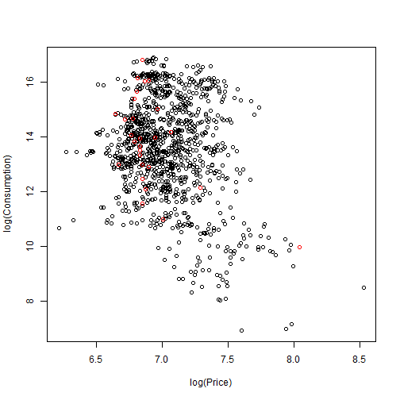

```r
plot(log(Consumption) ~ log(Price), data = subset(pp, Item == "Total Paper and Paperboard"))
points(log(Consumption) ~ log(Price), data = subset(pp, Item == "Total Paper and Paperboard" &
    Year == 2012), col = "red")
```

### All products

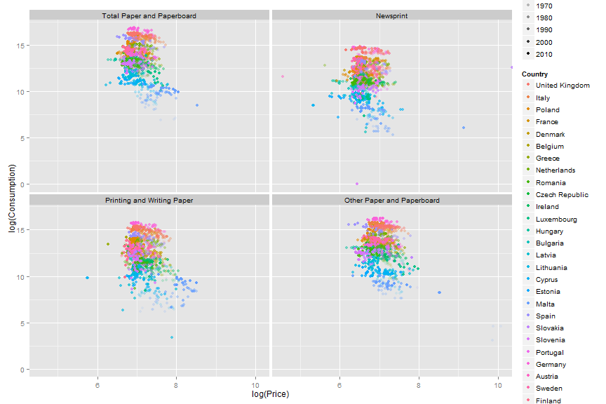

```r
p = ggplot(pp, aes(x = log(Price), y = log(Consumption), alpha = Year)) + facet_wrap(~Item)
p + geom_point(aes(color = Country, alpha = Year))
```

Countries that trade less seem to have higher prices.

Change point shapes with a “+” sign for positive net trade and a “o” sign for negative net trade. Show only Printing and writing paper for this graph.

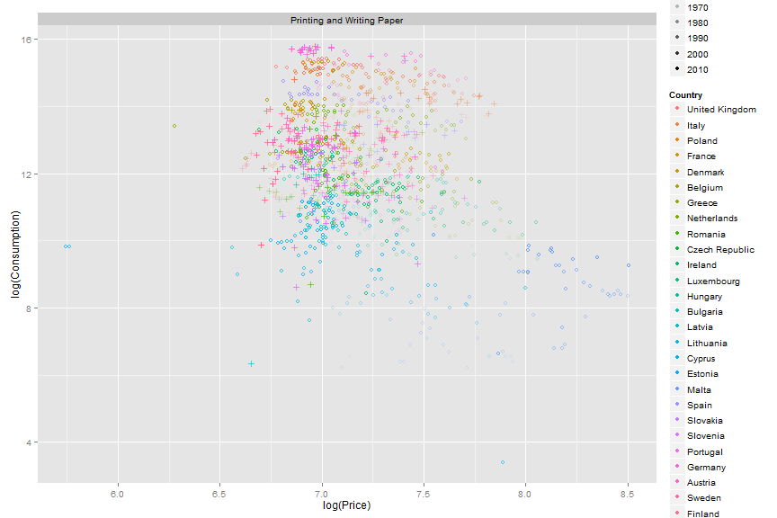

```r
p = ggplot(data = subset(pp, Item == "Printing and Writing Paper"), aes(x = log(Price),
    y = log(Consumption))) + facet_wrap(~Item)
p + scale_shape_identity() + geom_point(aes(color = Country, alpha = Year, shape = 1 +
    2 * (Net_Trade > 0)))
```